# comparing two proportions of high degree holders

## Setup

### Load packages

```r
library(ggplot2)
library(dplyr)
library(statsr)
```

### Load data

Make sure your data and R Markdown files are in the same directory. When loaded your data file will be called `gss`. Delete this note when before you submit. your work.

```r
load("gss.Rdata")
```

## Part 1: Data

The data in GSS are collected through asking about 50,000 Americans. The way they select the observation is by the random sampling of households from across the States, and they randomly pick one adult member of each selected household to complete the interview.

Since they randomly collect huge number of observations, data are independent from each other, closely following the normal distribution. We also can expect the Central Limit Theorem for the sampling. And, we are able to draw the correlation from the data, not the causality since it is from the observational study.

## Part 2: Research question

Is there any difference in the proportions of high degree holders, which are bachelor degree or higher, between Jewish people and others?

It is well known to everyone that Jewish people invest in education a lot, and they are dedicated to studying to get a high degree. But is it true story or just rumor? Comparing the proportion of higher degree among Jewish people and other people gives us the opportunity to see if the story is true.

## Part 3: Exploratory data analysis

```r
#filter the data by the religion. Name it as "jew"
jew <- filter(gss, relig == "Jewish")

#See what each data: degree looks like in "jew" and "gss"
summary(gss$degree)
```

```
## Lt High School    High School Junior College       Bachelor       Graduate
##          11822          29287           3070           8002           3870
##           NA's
##           1010
```

```r
summary(jew$degree)
```

```
## Lt High School    High School Junior College       Bachelor       Graduate
##            101            406             48            318            277
##           NA's
##              5
```

Next, we check what the data; “degree” looks like.

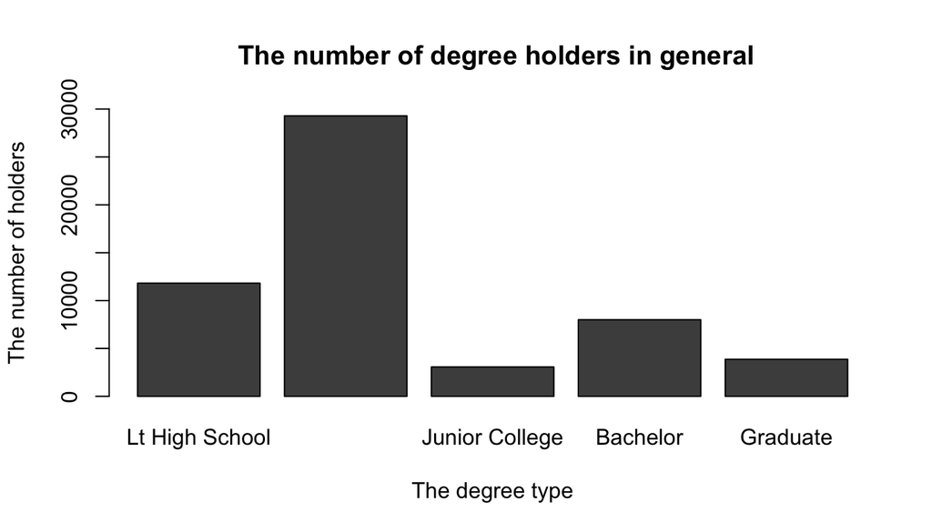

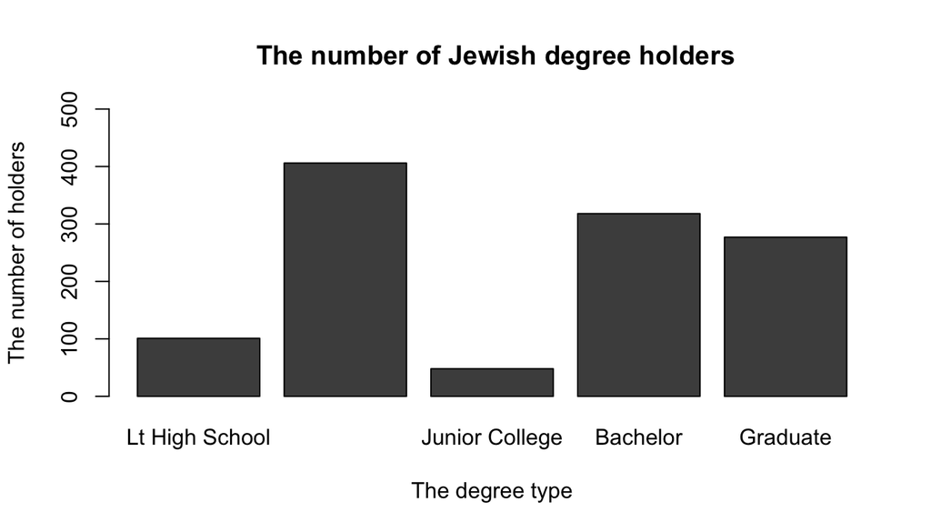

the summary tables of “degree” lets us check its proportion.

```r
#Check each table's proportion for "degree"
with(gss, prop.table(summary(gss$degree)))
```

```
## Lt High School    High School Junior College       Bachelor       Graduate
##     0.20718179     0.51325774     0.05380207     0.14023589     0.06782216
##           NA's
##     0.01770036
```

```r
with(jew, prop.table(summary(jew$degree)))
```

```
## Lt High School    High School Junior College       Bachelor       Graduate
##    0.087445887    0.351515152    0.041558442    0.275324675    0.239826840
##           NA's
##    0.004329004
```

As you can see, it seems that the ratio of high degrees is pretty high among Jewish people comapred to the ones in general. * * *

## Part 4: Inference

#Calculate the confidence interval for comparison of two population proportions.

Two Conditions are met: 1, two samples are independent of each other within the sample and between the sample. since both observations are less than 10% of the populatation and they both meets the success-failure condition. 2, each proportion separately follows a normal model. since the two observations are randomly selected.

First, set up the data frames for this calculation.

```r
#Make data frames for "gss"
id.gss <- c("Lt High School", "High School", "Junior College", "Bachelor", "Graduate")
ratio.gss <- c(0.21091506, 0.52250629, 0.05477155, 0.14276284, 0.06904426)
Dg <- data.frame(degree_type = id.gss, ratio_gss = ratio.gss)

#and do same calculations for "jew"
id.jew <- c("Lt High School", "High School", "Junior College", "Bachelor", "Graduate")
ratio.jew <- c( 0.08782609, 0.35304348, 0.04173913, 0.27652174, 0.24086957)
Dj <- data.frame(degree_type = id.jew, ratio_jew = ratio.jew)

#Combine both tables.
gj <- merge(Dg, Dj, by = "degree_type")
```

use the z-score to calculate since this test meets two conditions.

```r
# significant level = 5% which means that the confidence interval is 95%

#Check the total ratio of high degrees in both cases.
p.gss <- sum(gj[1,2], gj[2,2]) #the proportion of gss$bachelor and gss$graduate is 0.2118071
p.jew <- sum(gj[1,3], gj[2,3]) #the proportion of jew$bachelor and jew$graduate is 0.51739131

se <- sqrt((p.gss*(1-p.gss))/56051 +  (p.jew*(1-p.jew))/1150) #calculate the standard error

p.gss - p.jew + se*qnorm(c(0.025, 0.975)) # calculation for the 95% confidence interval
```

```
## [1] -0.3346622 -0.2765062
```

This says the 95% confidence interval for the difference of two proportions to be between -0.3346622 and -0.2765062. We are 95% confidence that the interval [-0.3346622 and -0.2765062] captures the true difference between the proportion of the overall high degree holders and the proportion in Jewish high degree holders.

#Conduct the Hypothesis test for Pg-Pj. ※Pg stands for the proportion of high degrees in the data “gss” and so as Pj.

Two Conditions are met: 1, two samples are independent of each other within the sample and between the sample. since both observations are less than 10% of the populatation and they both meets the success-failure condition. 2, each proportion separately follows a normal model. since the two observations are randomly selected.

```r
#H0: Pg = Pj
#HA: Pg ≠ Pj
#α = 0.05

#From summary, # of high degree holders are 595 out of 1150 in Jewish people, while 11872 out of 56051 in general.
prop.test(c(595, 11872), c(1150, 56051), alternative = c("greater"), conf.level = 0.95, correct = F)
```

```
##
##  2-sample test for equality of proportions without continuity
##  correction
##
## data:  c(595, 11872) out of c(1150, 56051)
## X-squared = 617.37, df = 1, p-value < 2.2e-16
## alternative hypothesis: greater
## 95 percent confidence interval:
##  0.2811812 1.0000000
## sample estimates:
##    prop 1    prop 2
## 0.5173913 0.2118071
```

Since p-value: 2.2e-16 is much lower than 0.05, we reject the null hypothesis. That is, we observe the difference between two proportions reasonably. We observe that the proportion of high degree holders among Jewish people are greater than the one in general.